```python
import pandas as pd
import numpy as np
import matplotlib as plt
```

```python
df = pd.read_csv('insurance-cost.csv')
```

# Data cleaning dan visual data exploratory

```python
df[10:20]
```

|  | age | sex | bmi | children | smoker | region | charges |
| --- | --- | --- | --- | --- | --- | --- | --- |
| 10 | 25 | male | 26.220 | 0 | no | northeast | 2721.32080 |
| 11 | 62 | female | 26.290 | 0 | yes | southeast | 27808.72510 |
| 12 | 23 | male | 34.400 | 0 | no | southwest | 1826.84300 |
| 13 | 56 | female | 39.820 | 0 | no | southeast | 11090.71780 |
| 14 | 27 | male | 42.130 | 0 | yes | southeast | 39611.75770 |
| 15 | 19 | male | 24.600 | 1 | no | southwest | 1837.23700 |
| 16 | 52 | female | 30.780 | 1 | no | northeast | 10797.33620 |
| 17 | 23 | male | 23.845 | 0 | no | northeast | 2395.17155 |
| 18 | 56 | male | 40.300 | 0 | no | southwest | 10602.38500 |
| 19 | 30 | male | 35.300 | 0 | yes | southwest | 36837.46700 |

Dapat dilihat bahwa data memiliki beberapa kolom, yaitu age, sex, bmi, children, smoker, region, dan charges.

```python
df.describe()
```

|  | age | bmi | children | charges |
| --- | --- | --- | --- | --- |
| count | 1338.000000 | 1336.000000 | 1338.000000 | 1338.000000 |
| mean | 39.207025 | 30.657481 | 1.094918 | 13270.422265 |
| std | 14.049960 | 6.100714 | 1.205493 | 12110.011237 |
| min | 18.000000 | 15.960000 | 0.000000 | 1121.873900 |
| 25% | 27.000000 | 26.272500 | 0.000000 | 4740.287150 |
| 50% | 39.000000 | 30.380000 | 1.000000 | 9382.033000 |
| 75% | 51.000000 | 34.681250 | 2.000000 | 16639.912515 |
| max | 64.000000 | 53.130000 | 5.000000 | 63770.428010 |

## Pengisian nilai kosong

```python
df.isnull().sum()
```

```
age         0
sex         0
bmi         2
children    0
smoker      2
region      0
charges     0
dtype: int64
```

Pada data di atas dapat kita lihat bahwa terdapat 2 kolom yang memiliki nilai null, yaitu kolom bmi dan smoker.

Kemudian untuk nilai kosong pada BMI akan diisi dengan nilai rata-rata (mean) sample pada jenis kelamin tersebut.

Untuk nilai kosong pada smoker akan diisi menggunakan menggunakan modus dari variabel pada sampel jadi jenis kelamin tersebut.

```python
df.iloc[:,2]
```

```
0       27.900
1       33.770
2       33.000
3       22.705
4       28.880
         ...
1333    30.970
1334    31.920
1335    36.850
1336    25.800
1337    29.070
Name: bmi, Length: 1338, dtype: float64
```

```python
df["bmi"] = df["bmi"].fillna(0)
```

```python
df["bmi"].isnull().sum()
```

```
0
```

```python
totalMaleBMI = 0
totalMale = 0

totalFemaleBMI = 0
totalFemale = 0

for i in range(0,len(df)):
    if df["sex"][i] == "male":
        totalMaleBMI += df["bmi"][i]
        totalMale += 1
    elif df["sex"][i] == "female":
        totalFemaleBMI += df["bmi"][i]
        totalFemale += 1

meanMaleBMI = totalMaleBMI/totalMale
meanFemaleBMI = totalFemaleBMI/totalFemale

print("Mean male BMI:", meanMaleBMI)
print("Mean female BMI:", meanFemaleBMI)
```

```
Mean male BMI: 30.890465976331342
Mean female BMI: 30.326948640483415
```

```python
emptyBMI = df[df['bmi'] == 0].index
for index in emptyBMI:
    if df["sex"][index] == "male":
        df.at[index,'bmi']= meanMaleBMI

    else:
        df.at[index,'bmi']= meanFemaleBMI
```

```python
df["bmi"].isnull().sum()
```

```
0
```

Setelah itu kita mengisi data yang kosong dari kolom smoker

```python
df["smoker"].isnull().sum()
```

```
2
```

```python
df["smoker"].unique()
```

```
array(['yes', 'no', nan], dtype=object)
```

```python
df["smoker"] = df["smoker"].fillna("empty")
df["smoker"].isnull().sum()
```

```
0
```

```python
totalMaleSmoker = 0
totalMaleNonSmoker = 0
totalFemaleSmoker = 0
totalFemaleNonSmoker = 0

for i in range(0,len(df)):
    if df["smoker"][i] != "empty":
        if df["sex"][i] == "male":
            if df["smoker"][i] == "yes":
                totalMaleSmoker += 1
            else:
                totalMaleNonSmoker += 1
        elif df["sex"][i] == "female":
            if df["smoker"][i] == "yes":
                totalFemaleSmoker += 1
            else:
                totalFemaleNonSmoker += 1

print("Total male smoker: ", totalMaleSmoker)
print("Total male non smoker: ", totalMaleNonSmoker)
print("Total female smoker: ", totalFemaleSmoker)
print("Total female non smoker: ", totalFemaleNonSmoker)
```

```
Total male smoker:  158
Total male non smoker:  517
Total female smoker:  115
Total female non smoker:  546
```

Dari data di atas dapat kita simpulkan untuk masing-masing modus pada jenis perokok untuk pada jenis kelamin masing-masing adalah:

```
laki-laki = non smoker
perempuan = non smoker
```

```python
emptySmoker = df[df['smoker'] == "empty"].index

for index in emptySmoker:
    if df["sex"][index] == "male":
        df.at[index, "smoker"] = "no"
    else:
        df.at[index, "smoker"] = "no"
```

```python
df.isnull().sum()
```

```
age         0
sex         0
bmi         0
children    0
smoker      0
region      0
charges     0
dtype: int64
```

# Penentuan independent variable dan perbandingan

```python
df.head()
```

|  | age | sex | bmi | children | smoker | region | charges |
| --- | --- | --- | --- | --- | --- | --- | --- |
| 0 | 19 | female | 27.900 | 0 | yes | southwest | 16884.92400 |
| 1 | 18 | male | 33.770 | 1 | no | southeast | 1725.55230 |
| 2 | 28 | male | 33.000 | 3 | no | southeast | 4449.46200 |
| 3 | 33 | male | 22.705 | 0 | no | northwest | 21984.47061 |
| 4 | 32 | male | 28.880 | 0 | no | northwest | 3866.85520 |

```python
df.tail()
```

|  | age | sex | bmi | children | smoker | region | charges |
| --- | --- | --- | --- | --- | --- | --- | --- |
| 1333 | 50 | male | 30.97 | 3 | no | northwest | 10600.5483 |
| 1334 | 18 | female | 31.92 | 0 | no | northeast | 2205.9808 |
| 1335 | 18 | female | 36.85 | 0 | no | southeast | 1629.8335 |
| 1336 | 21 | female | 25.80 | 0 | no | southwest | 2007.9450 |
| 1337 | 61 | female | 29.07 | 0 | yes | northwest | 29141.3603 |

Dalam data di atas, kita dapat melakukan visualisasi untuk melihat apakah masing-masing variabel memiliki hubungan antara 1 dengan yang lainnya

## Pemeriksaan kolom charges

```python
import seaborn as sns
```

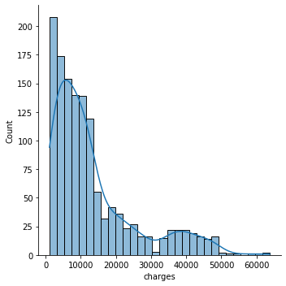

```python
sns.displot(data = df, x = df['charges'], kde=True)
```

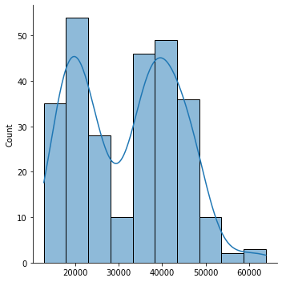

```python
sns.displot(df.loc[df.smoker == 'yes']['charges'].values.tolist(), kde=True)
```

Dapat kita lihat secara sekilas bahwa pelanggan perokok memiliki biaya premi asuransi yang tinggi pada angka 20000 dan 35000-40000

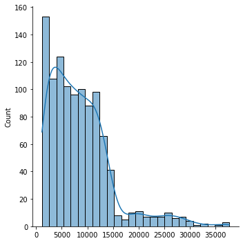

```python
sns.displot(df.loc[df.smoker == 'no']['charges'].values.tolist(), kde=True)
```

Sedangkan untuk pelanggan non perokok memiliki biaya premi yang lebih rendah, yakni dari dibawah 5000 hingga 15000

## Pemeriksaan kolom age

Oleh karena asuransi identik dengan umur, maka kita akan memeriksa data yang dimiliki oleh age

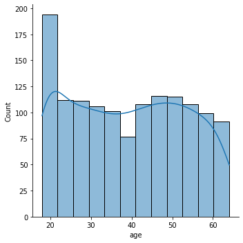

```python
sns.displot(data = df, x = df["age"], kde=True)
```

Dari visualisasi data di atas, kita melihat bahwa pemilik asuransi mayoritas berada pada umur awal 20an

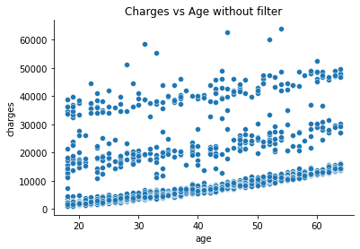

```python
sns.scatterplot(x= df['age'] , y= df['charges']).set_title('Charges vs Age without filter')
sns.despine()
```

Perbandingan umur dengan biaya premi di atas dapat kita lihat bahwa semakin tua, maka akan semakin tinggi biayanya, sehingga sangat terlihat bawah ada hubungan yang erat antara umur dengan biaya premi. Maka diperlukan filter untuk dapat melihat apa lagi pengaruh yang mendukung trend seperti ini

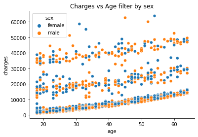

```python
sns.scatterplot(x= df['age'] , y= df['charges'], hue='sex', data=df).set_title('Charges vs Age filter by sex')
sns.despine()
```

Kemudian ketika kita lihat lagi mengenai jenis kelamin antara perbandingan antara biaya premi dengan umur, cukup beragam keterlibatan jenis kelamin terhadap perbandingan umur dengan harga premi, namun tidak terlihat memiliki pengaruh yang besar dalam penentuan harga premi dengan umur

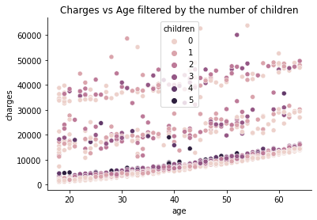

```python
sns.scatterplot(x= df['age'] , y= df['charges'], hue='children', data=df).set_title('Charges vs Age filtered by the number of children')
sns.despine()
```

Kemudian perbandingan antara umur dengan harga dari premi yang difilter dengan jumlah anak, pada bagian bawah dari visualisasi bahwa ada sedikit hubungan antara jumlah anak dengan perbandingan antara umur dengan harga.

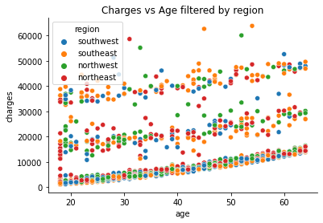

```python
sns.scatterplot(x= df['age'] , y= df['charges'], hue='region', data=df).set_title('Charges vs Age filtered by region')
sns.despine()
```

Pada perbandingan antara umur dengan harga yang difilter dengan region kurang menunjukkan pola yang jelas mengenai pengaruh dari region terhadap harga biaya premi.

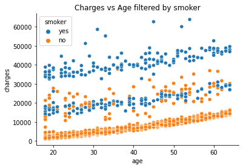

```python
sns.scatterplot(x= df['age'] , y= df['charges'], hue='smoker', data=df).set_title('Charges vs Age filtered by smoker')
sns.despine()
```

Pada visualisasi di atas, dapat kita lihat bahwa adanya hubungan erat antara biaya premi terhadap umur untuk orang yang merokok dan non perokok. Biaya premi yang harus dibayar oleh mayoritas pelanggan perokok dapat terlihat lebih tinggi dari pada mayoritas pelanggan non perokok

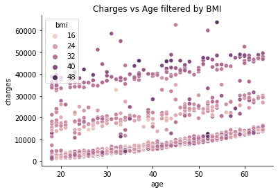

```python
sns.scatterplot(x= df['age'] , y= df['charges'], hue='bmi', data=df).set_title('Charges vs Age filtered by BMI')
sns.despine()
```

Pada visualisasi data di atas, dapat kita lihat bahwa terdapat hubungan antara BMI dengan perbandingan umur dan harga premi. Bahwa harga dan umur juga dipengaruhi oleh rendah tingginya BMI pelanggan.

## Pemeriksaan kolom BMI

Selanjutnya adalah pemeriksaan data BMI dan hubungannya terhadap harga

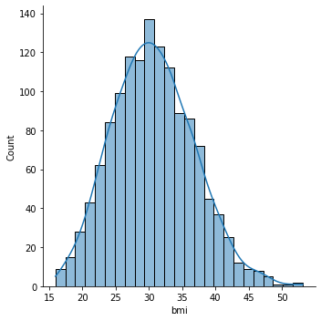

```python
sns.displot(data = df, x = df["bmi"], kde=True)
```

Dapat dilihat bahwa mayoritas BMI dari pelanggan asuransi paling banyak berada pada angka 25 hingga 35

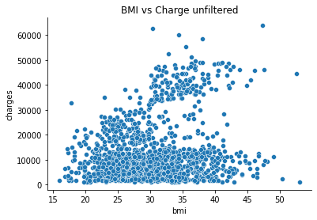

```python
sns.scatterplot(x= df['bmi'] , y= df['charges'], data=df).set_title('BMI vs Charge unfiltered')
sns.despine()
```

Kita melihat bahwa tidak ada hubungan yang jelas antara BMI seseorang dengan harga

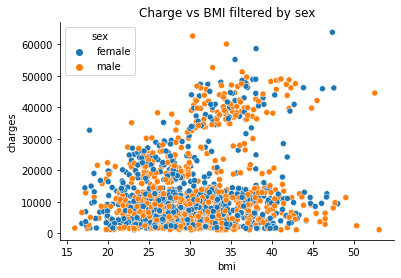

```python
sns.scatterplot(x= df['bmi'] , y= df['charges'], hue="sex", data=df).set_title('Charge vs BMI filtered by sex')
sns.despine()
```

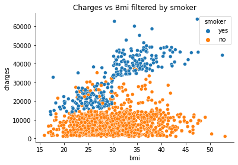

```python
sns.scatterplot(x= df['bmi'] , y= df['charges'], hue='smoker', data=df).set_title('Charges vs Bmi filtered by smoker')
sns.despine()
```

Dari visualisasi data di atas, dapat dilihat polanya bahwa seorang perokok cenderung memiliki biaya premi yang lebih tinggi meskipun memiliki BMI yang rendah. Namun semakin tinggi BMI yang dimiliki diikuti dengan sifat perokok, maka harga premi akan jauh lebih tinggi.

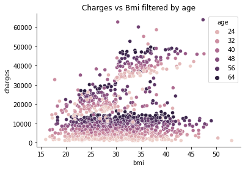

```python
sns.scatterplot(x= df['bmi'] , y= df['charges'], hue='age', data=df).set_title('Charges vs Bmi filtered by age')
sns.despine()
```

Pada visualisasi di atas kita dapat melihat bahwa terdapat pola dari umur pelanggan terhadap perbandingan BMI dengan biaya premi. Pada setiap range BMI, pertambahan umur akan menyebabkan pertambahan biaya premi.

Namun seperti yang dapat kita lihat dari filter perokok, maka harga premi juga semakin tinggi.

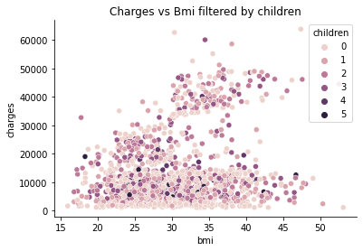

```python
sns.scatterplot(x= df['bmi'] , y= df['charges'], hue='children', data=df).set_title('Charges vs Bmi filtered by children')
sns.despine()
```

Visualisasi di atas menunjukkan kurangnya pengaruh dari jumlah anak terhadap perbandingan BMI dengan harga premi

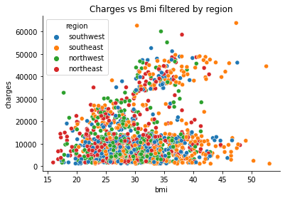

```python
sns.scatterplot(x= df['bmi'] , y= df['charges'], hue='region', data=df).set_title('Charges vs Bmi filtered by region')
sns.despine()
```

Visualisasi di atas menunjukkan kurangnya pengaruh dari region terhadap perbandingan BMI dan harga premi

## Pemeriksaan kolom Children

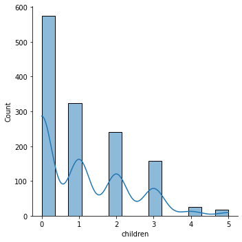

```python
sns.displot(data = df, x = df["children"], kde=True)
```

Mayoritas jumlah anak dari pemegang asuransi adalah sejumlah 0

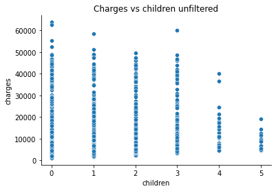

```python
sns.scatterplot(x= df['children'] , y= df['charges'], data=df).set_title('Charges vs children unfiltered')
sns.despine()
```

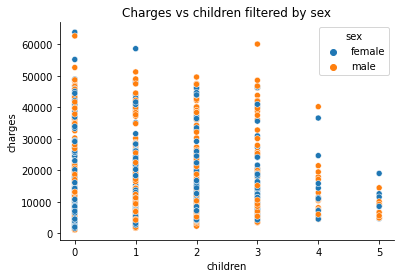

```python
sns.scatterplot(x= df['children'] , y= df['charges'], hue = "sex", data=df).set_title('Charges vs children filtered by sex')
sns.despine()
```

Tidak terlihat pengaruh dari jenis kelamin terhadap perbandingan jumlah anak dengan harga premi

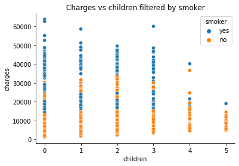

```python
sns.scatterplot(x= df['children'] , y= df['charges'], hue = "smoker", data=df).set_title('Charges vs children filtered by smoker')
sns.despine()
```

Dapat dilihat bahwa sifat perokok atau non perokok juga mempengaruhi perbandingan antara jumlah anak dengan harga premi

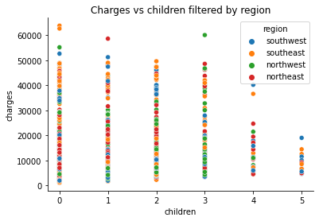

```python
sns.scatterplot(x= df['children'] , y= df['charges'], hue = "region", data=df).set_title('Charges vs children filtered by region')
sns.despine()
```

Tidak terlihat adanya pengaruh dari region kepada perbandingan antara jumlah anak dengan biaya premi

## Pemeriksaan kolom smoker

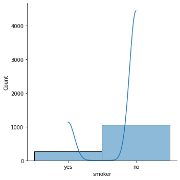

```python
sns.displot(data = df, x = df["smoker"], kde=True)
```

Dapat kita lihat bahwa mayoritas pemegang asuransi tidak merokok

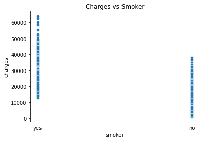

```python
sns.scatterplot(x= df['smoker'] , y= df['charges'], data=df).set_title('Charges vs Smoker')
sns.despine()
```

Dapat kita lihat bahwa perokok memiliki biaya asuransi yang lebih tinggi dari pada non perokok

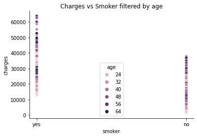

```python
sns.scatterplot(x= df['smoker'] , y= df['charges'], hue= "age", data=df).set_title('Charges vs Smoker filtered by age')
sns.despine()
```

Kurang terlihat adanya pengaruh dari umur terhadap perbandingan dari smoker dan harga premi asuransi

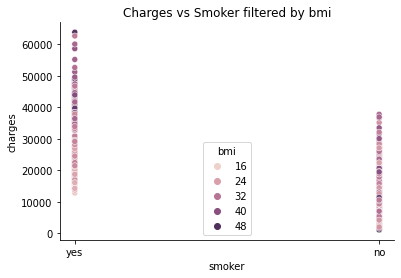

```python
sns.scatterplot(x= df['smoker'] , y= df['charges'], hue= "bmi", data=df).set_title('Charges vs Smoker filtered by bmi')
sns.despine()
```

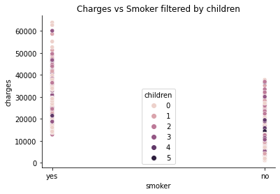

```python
sns.scatterplot(x= df['smoker'] , y= df['charges'], hue= "children", data=df).set_title('Charges vs Smoker filtered by children')
sns.despine()
```

Kurang terlihat pengaruh dari jumlah anak terhadap perbandingan sifat perokok dengan biaya premi asuransi

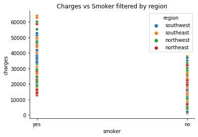

```python
sns.scatterplot(x= df['smoker'] , y= df['charges'], hue= "region", data=df).set_title('Charges vs Smoker filtered by region')
sns.despine()
```

Kurang terlihat pengaruh dari region terhadap perbandingan sifat perokok dengan biaya premi asuransi